# Demographics of American Food Lovers

Julianne Zech

6/2/2019

## Introduction

In this post, I am working with [data](https://github.com/fivethirtyeight/data/blob/master/food-world-cup/food-world-cup-data.csv) collected by FiveThirtyEight as part of their [Food World Cup](https://fivethirtyeight.com/features/the-fivethirtyeight-international-food-associations-2014-world-cup/) project. The survey asked respondents to rate the national cuisines of the thirty-two teams that qualified for the 2014 World Cup, as well as eight wildcard countries: China, Cuba, Ethiopia, India, Ireland, Thailand, Turkey and Vietnam. A score of 5 means that the respondent “love this country’s traditional cuisine” and “thinks it’s one of the best in the world” and a 1 means the opposite. Respondents were also allowed to opt out if they were unfamiliar with the country’s food scene. All respondents also self-labeled their own food knowledge. They could answer the question “Generally speaking, how would you rate your level of knowledge of cuisines from different parts of the world?” with either “novice”, “intermediate”, or “advanced.” Similarly, the could answer “How much, if at all, are you interested in cuisines from different parts of the world?” with either “not much”, “some”, or “a lot.” Respondents were also asked to provide their gender, age range, household income range, education level, and region.

## Task

My goal is to design and build a series of visual displays that describe the differences (and/or similarities) between two or more groups in terms of at least two categorical variables. I will define one group as the respondents who claimed they have advanced or expert knowledge of global cuisines and a lot of interest in learning about cuisines from different parts of the world. The second group will consist of respondents who claimed they have only novice knowledge and not much interest in expanding their palettes. I would like to determine whether or not these groups have significant demographic differences, i.e. whether people’s interest in global cuisine has a strong correlation with their geographic location, gender, and/or socioeconomic status. It would be logical to think that people with higher household incomes are more likely to consider themselves “foodies”, but perhaps this is not the case.

## Data Pre-Processing

First, I will read the data into a data.frame object. Next, I’ll subset the data to create the two groups of interest and add a variable “Group” with levels “foodies” and “non-foodies” to label members of each group.

```r
# read in the data
food <- read_csv("food-world-cup-data.txt", col_names = T, locale = locale(encoding = "latin1"))
```

```r
# change column names to something shorter and easier to work with
colnames(food)[2] = 'Food_Knowledge'
colnames(food)[3] = 'Food_Interest'

# relevel education variable: order from lowest to highest education
food = mutate(food, Education = fct_relevel(Education, "Less than high school degree", "High school degree", "Some college or Associate degree", "Bachelor degree",  "Graduate degree"))

# rename education variables so graph labels don't overlap
food = mutate(food, Education = fct_recode(Education, "Less than\nhigh school\ndegree" = "Less than high school degree", "High school\ndegree" = "High school degree","Some college\nor Associate\ndegree" = "Some college or Associate degree", "Bachelor\ndegree" = "Bachelor degree",  "Graduate\ndegree" = "Graduate degree"))

# relevel age variable: order from lowest to highest age
food = mutate(food, Age = fct_relevel(Age, "18-29", "30-44", "45-60", "> 60"))

# relevel income variable: order from lowest to highest income
food = mutate(food, `Household Income` = fct_relevel(`Household Income`, "$0 - $24,999", "$25,000 - $49,999",
                                                     "$50,000 - $99,999", "$100,000 - $149,999", "$150,000+"))


# create foodies group
foodies <- dplyr::filter(food, (Food_Knowledge == "Advanced" | Food_Knowledge == "Expert") & Food_Interest == "A lot")
foodies["Group"] = "foodies"

# create non_foodies group
non_foodies <- filter(food, Food_Knowledge == "Novice"
                      & Food_Interest == "Not muchÊ")
non_foodies["Group"] = "non-foodies"

# see how many respondents are in each group
dim(foodies)
```

```
## [1] 167  49
```

```r
dim(non_foodies)
```

```
## [1] 149  49
```

```r
# combine the groups into one data set
food_groups <- rbind(foodies, non_foodies)
```

We can see that there are 167 respondents in the “foodies” group and 149 in the “non-foodies” group. Since our group sizes are fairly close to one another, we should be able to draw some interesting comparisons.

## Education by Food Group

Above the code for each graph, I’ll outline a grammar of graphics breakdown to describe the aesthetic components and statistical basis. Below each finished display, I’ll record some observations about what the graph reveals about the data. The first graph is a side-by-side barplot of education level for members of each group.

**Data**

- The data used to create this visualization is the education variable that has five levels. Let’s show the table consisting of 3 observations that exemplify what the raw, underlying data looks like.

```r
food_groups[1:3, c("Education", "Group")]
```

```
## # A tibble: 3 x 2
##   Education                            Group
##   <fct>                                <chr>
## 1 "Graduate\ndegree"                   foodies
## 2 "Some college\nor Associate\ndegree" foodies
## 3 "Bachelor\ndegree"                   foodies
```

**Statistical Transformations**

- The y axis scale of this graph results from computing the denominator of the relative frequency fraction per group using the group_by() function. This transformation is necessary to see the relative frequency of education dependent on group, not the relative frequency of each combination of education and group. To calculate the relative frequency of foodies with graduate degrees, we divide the number of foodies with graduate degrees (47) by the number of foodies (167) to obtain ~28.1%. The same calculation us applied to each level for each group. Below, we can see the tables of the transformed data.

```r
summary_foodies <- summarize(group_by(foodies, Education, Group), count=n())
summary_foodies$percent <- summary_foodies$count/sum(summary_foodies$count)
summary_non_foodies <- summarize(group_by(non_foodies, Education, Group), count=n())
summary_non_foodies$percent <- summary_non_foodies$count/sum(summary_non_foodies$count)

summary_foodies
```

```
## # A tibble: 6 x 4
## # Groups:   Education [?]
##   Education                            Group   count percent
##   <fct>                                <chr>   <int>   <dbl>
## 1 "Less than\nhigh school\ndegree"     foodies     1 0.00599
## 2 "High school\ndegree"                foodies    11 0.0659
## 3 "Some college\nor Associate\ndegree" foodies    33 0.198
## 4 "Bachelor\ndegree"                   foodies    59 0.353
## 5 "Graduate\ndegree"                   foodies    47 0.281
## 6 <NA>                                 foodies    16 0.0958
```

```r
summary_non_foodies
```

```
## # A tibble: 6 x 4
## # Groups:   Education [?]
##   Education                            Group       count percent
##   <fct>                                <chr>       <int>   <dbl>
## 1 "Less than\nhigh school\ndegree"     non-foodies     6  0.0403
## 2 "High school\ndegree"                non-foodies    18  0.121
## 3 "Some college\nor Associate\ndegree" non-foodies    54  0.362
## 4 "Bachelor\ndegree"                   non-foodies    32  0.215
## 5 "Graduate\ndegree"                   non-foodies    30  0.201
## 6 <NA>                                 non-foodies     9  0.0604
```

```r
summary_data <- rbind(summary_foodies, summary_non_foodies)
summary_data
```

```
## # A tibble: 12 x 4
## # Groups:   Education [6]
##    Education                            Group       count percent
##    <fct>                                <chr>       <int>   <dbl>
##  1 "Less than\nhigh school\ndegree"     foodies         1 0.00599
##  2 "High school\ndegree"                foodies        11 0.0659
##  3 "Some college\nor Associate\ndegree" foodies        33 0.198
##  4 "Bachelor\ndegree"                   foodies        59 0.353
##  5 "Graduate\ndegree"                   foodies        47 0.281
##  6 <NA>                                 foodies        16 0.0958
##  7 "Less than\nhigh school\ndegree"     non-foodies     6 0.0403
##  8 "High school\ndegree"                non-foodies    18 0.121
##  9 "Some college\nor Associate\ndegree" non-foodies    54 0.362
## 10 "Bachelor\ndegree"                   non-foodies    32 0.215
## 11 "Graduate\ndegree"                   non-foodies    30 0.201
## 12 <NA>                                 non-foodies     9 0.0604
```

**Geometric Objects**

- Rectangles are used to form a bar graph. The height of the bars represent the number of survey respondents in a certain group with a certain level of education.

**Aesthetic Mappings**

- The x aesthetic is mapped to the Education variable.
- The fill of the bars is mapped to the Groups variable.
- The y aesthetic is mapped to the percent of respondents who have reached each education level dependent on their group (i.e., the combined height of all light purple bars is equal to 1 and the height of all dark purple bars is equal to 1). To show these transformed values in the graph, I set y equal to our calculated percent column in the geom_bar() function and specified that stat=“identity”, which maps the height of the bars to the y aesthetic.

**Scales**

- Each value of the location variable is mapped to an x-coordinate where the bars are located. The coordinates are evenly spaced apart.
- Each level of the group variable is mapped to a unique color (light purple for foodies and dark purple for non-foodies).
- Each percent value for each group is mapped to a height that corresponds to its value relative to the other bars.

**Position Adjustments/Collision Modifiers**

- This graph uses the “dodge” position adjustment, which preserves the vertical position of an geom while adjusting the horizontal position (i.e., plots the bars side-by-side)

**Coordinate Systems**

- This graph uses the standard cartesian coordinate system.

**Faceting**

- This visualization is not faceted. i’ve constructed summary data that allows us to plot the data for both groups side-by-side.

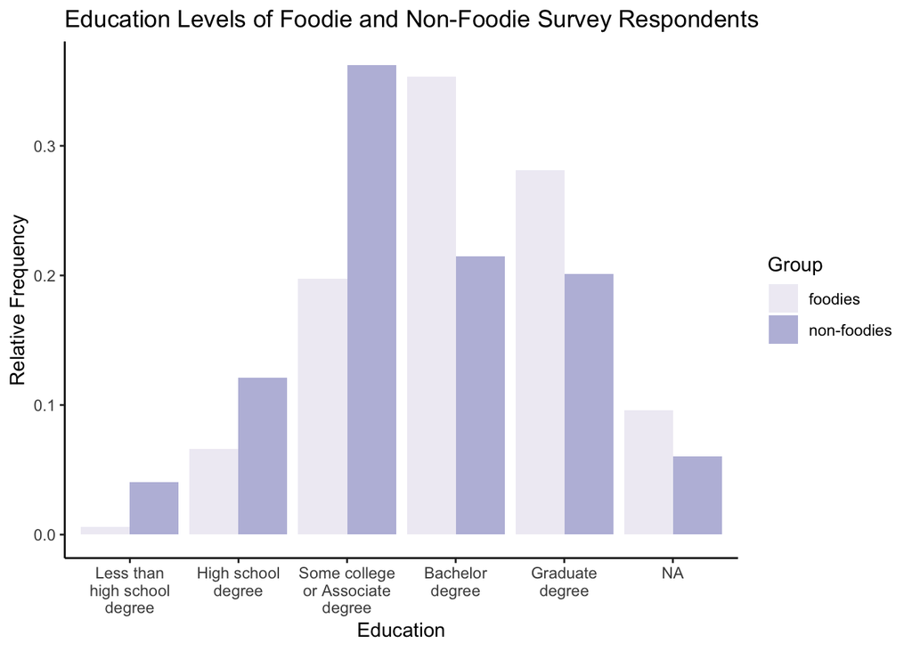

```r
ggplot(summary_data) + geom_bar(aes(x=Education, fill=Group, y=percent), position="dodge", stat="identity") + theme_classic() + scale_fill_brewer(palette="Purples", na.value="gray") + labs(title="Education Levels of Foodie and Non-Foodie Survey Respondents", y="Relative Frequency")
```

## Location by Food Group

**Data**

```r
food_groups[1:3, c("Location (Census Region)", "Group")]
```

```
## # A tibble: 3 x 2
##   `Location (Census Region)` Group
##   <chr>                      <chr>
## 1 East North Central         foodies
## 2 South Atlantic             foodies
## 3 Mountain                   foodies
```

**Statistical Transformations**

- Since there are so many levels, I decided to consense the levels into four geographic regions: West, Midwest, South, and Northeast. The results of this aggregation can be shown in the data table below.

```r
# make column name shorter and one word
colnames(food_groups)[48] = "Location"

# collapse factor levels into manually defined groups
food_groups = mutate(food_groups, Location = fct_collapse(Location, "Northeast" = c("Middle Atlantic", "New England"), "South" = c("South Atlantic", "East South Central", "West South Central"), "Midwest" = c("West North Central", "East North Central"), "West" = c("Pacific", "Mountain")))

# relevel age variable: order from West to East (roughly)
food_groups = mutate(food_groups, Location = fct_relevel(Location, "West", "Midwest", "South", "Northeast"))

food_groups[1:3, c("Location", "Group")]
```

```
## # A tibble: 3 x 2
##   Location Group
##   <fct>    <chr>
## 1 Midwest  foodies
## 2 South    foodies
## 3 West     foodies
```

**Geometric Objects**

- Rectangles are used to form a bar graph. The height of the bars represent the number of survey respondents in a certain group (foodies or non-foodies) who live in each geographic area of the U.S.

**Aesthetic Mappings**

- The x aesthetic and the fill of the bars are mapped to the Location variable.
- The y aesthetic is mapped to the count of respondents (with a scale that will be addressed below).

**Scales**

- Each level for Location is mapped to a unique x-coordinate (since there are two graphs that are faceted, each level appears twice in the finished display).
- Each level for location is mapped to a unique color that fills the bars.
- The relative frequency shown on the y-axis is scaled to represent the relative frequency of location dependent on group, not the relative frequency of each combination of location and group. The count of each number of respondents in each location is divided by the count of each panel/group. This is the same scale applied in the previous graph achieved in a different way.

**Position Adjustments/Collision Modifiers**

- No position adjustments were necessary.

**Coordinate Systems**

- The graph is plotted on the standard Cartesian coordinate system.

**Faceting**

- The visualization is faceted by group. That is, it consists of two graphs that each shows the distribution of location for that group. The resulting graphs are positioned next to each other for easy visual comparison of bar heights.

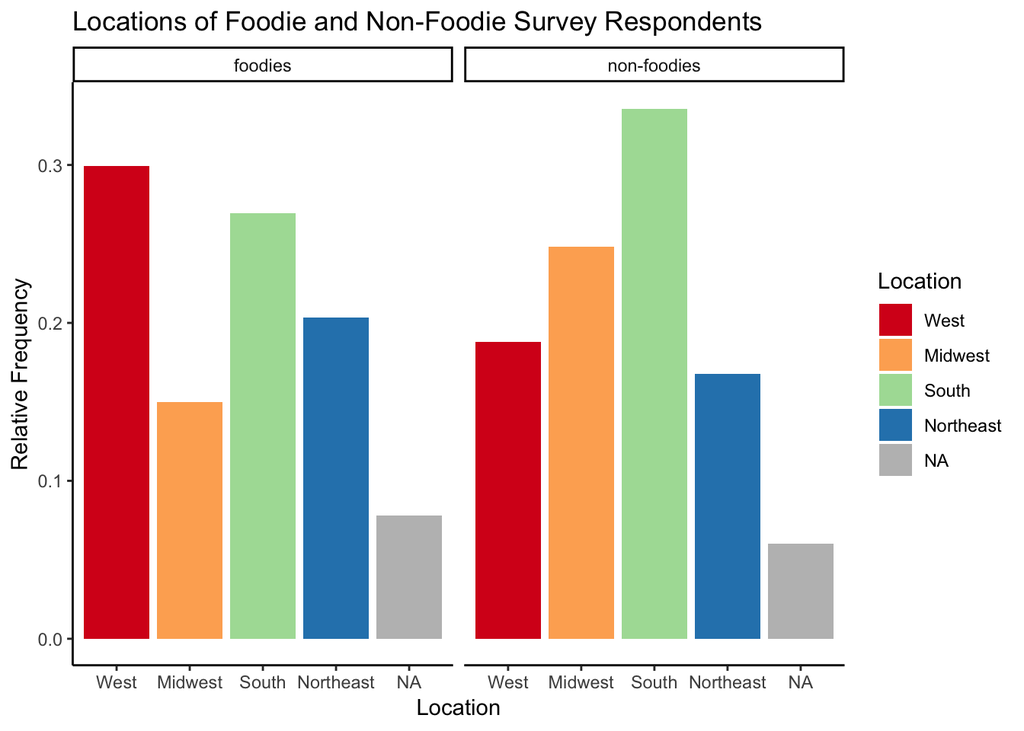

```r
ggplot(food_groups) + geom_bar(aes(x=Location, fill=Location, y = (..count..)/tapply(..count..,..PANEL..,sum)[..PANEL..])) + facet_wrap("Group") + labs(title="Locations of Foodie and Non-Foodie Survey Respondents", y="Relative Frequency") + scale_fill_brewer(palette="Spectral", na.value="gray") + theme_classic()
```

From these graphs, we can see that a greater relative frequency of survey respondents in the foodies group reside in the West and South than the Northeast and Midwest. Similarly, a greater percentage of respondents in the non-foodies group reside in the South and the Midwest than the West and Northeast. The relative frequencies of respondents in the West and Northeast are higher in the foodies group than the non-foodies group, and the opposite is true for the Midwest and the South. This result seems intuitive. People who live on the coasts, expecially in cities like San Franciscso and New York often have more exposure to a variety of international cuisines than those in the South and Midwest, and that accessibility is likely correlated with greater knowledge and interest. We can collapse the levels in our original food data frame to see the distribution of overall respondents in the survey. All regions have fairly similar representation in the survey, which strengthens the validity of our observations.

```r
# collapse factor levels into manually defined groups
food = mutate(food, Location = fct_collapse(`Location (Census Region)`, "Northeast" = c("Middle Atlantic", "New England"), "South" = c("South Atlantic", "East South Central", "West South Central"), "Midwest" = c("West North Central", "East North Central"), "West" = c("Pacific", "Mountain")))

summary(food$Location)
```

```
##   Midwest     South Northeast      West      NA's
##       295       374       243       317       144
```

## Gender by Food Group

**Data**

```r
food_groups[1:3, c("Gender", "Group")]
```

```
## # A tibble: 3 x 2
##   Gender Group
##   <chr>  <chr>
## 1 Female foodies
## 2 Male   foodies
## 3 Male   foodies
```

**Statistical Transformations**

- No statistical transformations were performed on the data.

**Geometric Objects**

- A bar of height 1 represents the frequency distribution of gender for each group.

**Aesthetic Mappings**

- The x aesthetic is mapped to the group variable (foodies or non-foodies).
- The fill of the bars are mapped to the relative frequencies of gender for each group.

**Scales**

**Position Adjustments/Collision Modifiers**

- No position adjustments were made.

**Coordinate Systems**

- The graph is plotted on the standard Cartesian coordinate system.

**Faceting**

- This graph is not faceted. Instead, both groups are depicted on the same graph.

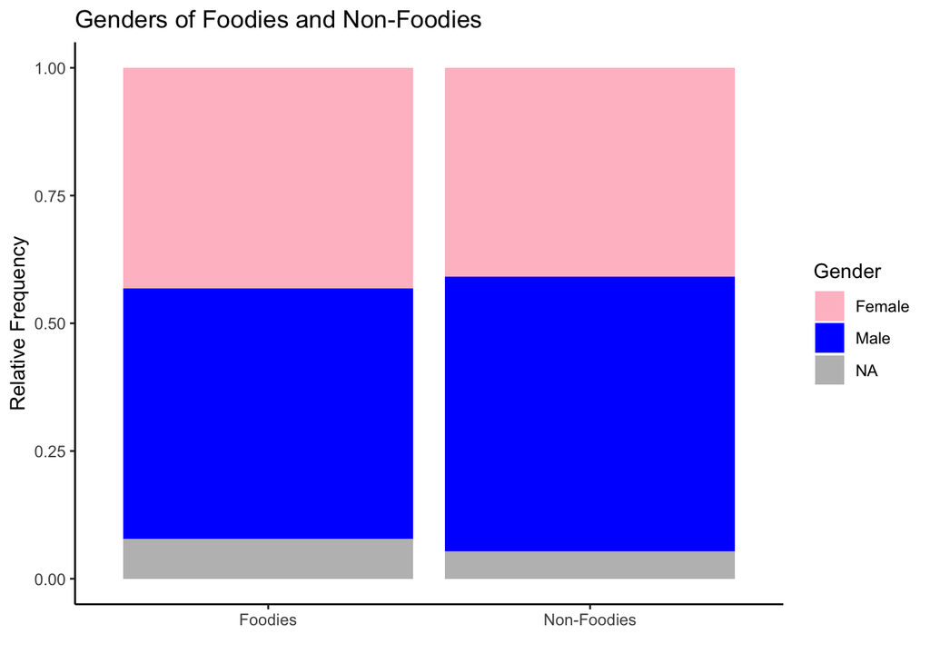

```r
ggplot(food_groups) + geom_bar(aes(x=Group, fill=Gender), position="fill") +
  labs(x="",y="Relative Frequency", title="Genders of Foodies and Non-Foodies") +
  scale_x_discrete(labels=c("Foodies","Non-Foodies")) + scale_fill_manual(values=c("pink", "blue"), na.value="gray") +
  theme_classic()
```

```r
summary(foodies$Gender == "Female")
```

```
##    Mode   FALSE    TRUE    NA's
## logical      82      72      13
```

```r
summary(non_foodies$Gender == "Female")
```

```
##    Mode   FALSE    TRUE    NA's
## logical      80      61       8
```

From the graph, we can see that there is not much of a difference in the gender distributions between each group. Each group contains roughly the same amount of males as females with a few NA values. It seems unsurprising that interest in the food of other cultures does not have a strong correlation with gender. I would expect to see a stronger correlation with other variables such as location and age.

## Age by Food Group

**Data**

- The data used to create this display is the age variable that has four levels. The first three rows of the table are shown below.

```r
food_groups[1:3, c("Age", "Group")]
```

```
## # A tibble: 3 x 2
##   Age   Group
##   <fct> <chr>
## 1 30-44 foodies
## 2 45-60 foodies
## 3 30-44 foodies
```

**Statistical Transformations**

- The y aesthetic is scaled with a square root transformation using scale_y_sqrt()

**Geometric Objects**

- Wedges are used to represent the Age variable in the data.

**Aesthetic Mappings**

- The fill and color are mapped to the Age variable to represent the different age brackets.
- The y aesthetic, which represents the relative frequency of respondents in each age bracket, is mapped to the radius of each wedge.

**Scales**

- Each level of Age has its own unique fill and color (the fill for a certain level of Age is the same as the color for that same level).
- The y aesthetic is scaled with a square root transformation using scale_y_sqrt() so that the area of the wedge will be proportional to the relative frequency.

**Position Adjustments/Collision Modifiers**

- No position adjustments were necessary.

**Coordinate Systems**

- This graph uses a polar coordinate system.

**Faceting**

- These graphs are not faceted, although they are positioned side-by-side using the grid.arrange() function. Faceting would have been a natural choice here since they are helpful for making similar plots for different group, but I wanted to explore the grid functionality.

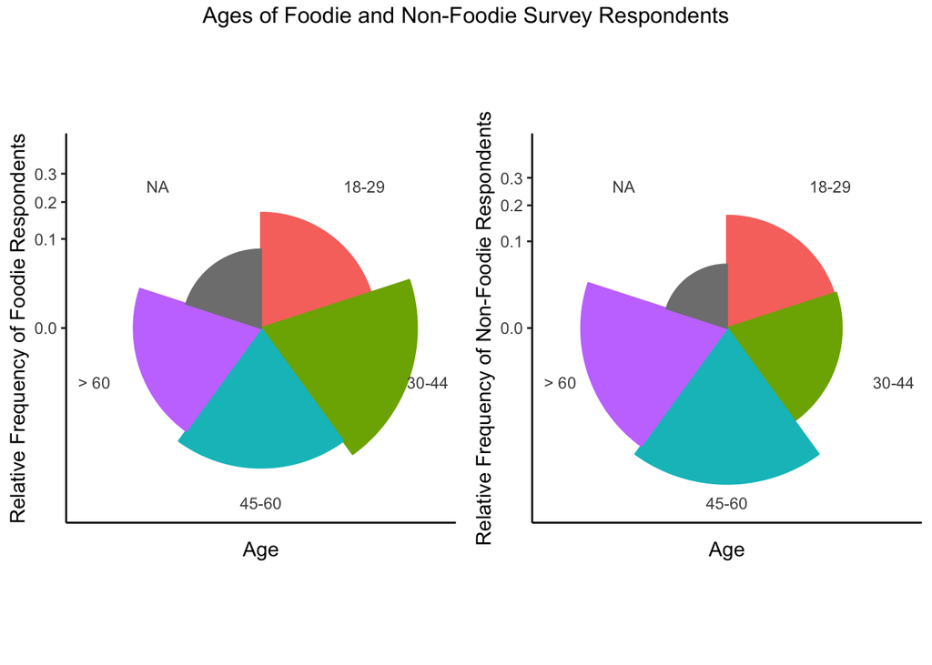

```r
age1 <- ggplot(foodies) + geom_bar(aes(x=Age, fill=Age, color=Age, y=..count../sum(..count..)), width=1) + coord_polar() + scale_y_sqrt() + theme_classic() + theme(legend.position="none") + labs(y="Relative Frequency of Foodie Respondents")

age2 <- ggplot(non_foodies) +  geom_bar(aes(x=Age, fill=Age, color=Age, y=..count../sum(..count..)), width=1) + coord_polar() + scale_y_sqrt() + theme_classic()  + theme(legend.position="none") + labs(y="Relative Frequency of Non-Foodie Respondents")

grid.arrange(age1, age2, top = "Ages of Foodie and Non-Foodie Survey Respondents", nrow=1)
```

## Income by Food Group

**Data**

- The data used to create this display is the annual household income variable that has five levels. The first three rows of the underlying data are shown below.

```r
food_groups[1:3, c("Household Income", "Group")]
```

```
## # A tibble: 3 x 2
##   `Household Income` Group
##   <fct>              <chr>
## 1 $50,000 - $99,999  foodies
## 2 $0 - $24,999       foodies
## 3 $50,000 - $99,999  foodies
```

**Statistical Transformations**

- No statistical transformation were performed.

**Geometric Objects**

- Rectangles are used to form a bar graph. The height of the bars represent the number of survey respondents in a certain group whose annual household income falls in each designated range.

**Aesthetic Mappings**

- The x aesthetic is mapped to Annual Household Income.
- The fill of the bars is mapped to Annual Household Income.
- The y aesthetic represents the relative frequency of income dependent on group.

**Scales**

- Each levels for annual household income has its own unique x-coordinate (since the two graphs are faceted, each level has two unique x-coordinates twice in the finished display).
- Each level for annual household income has its own unique color (darker green for higher income and gray for NA).
- The relative frequency shown on the y-axis is scaled to represent the relative frequency of location dependent on group. The count of each number of respondents in each location is divided by the count of each group.

**Position Adjustments/Collision Modifiers**

- No position adjustments were necessary.

**Coordinate Systems**

- This graph uses the standard Cartesian coordinate system.

**Faceting**

- Like the second display showing geographic locations, this visualization is faceted by group. It consists of two graphs that each shows the distribution of household income for that particular group.

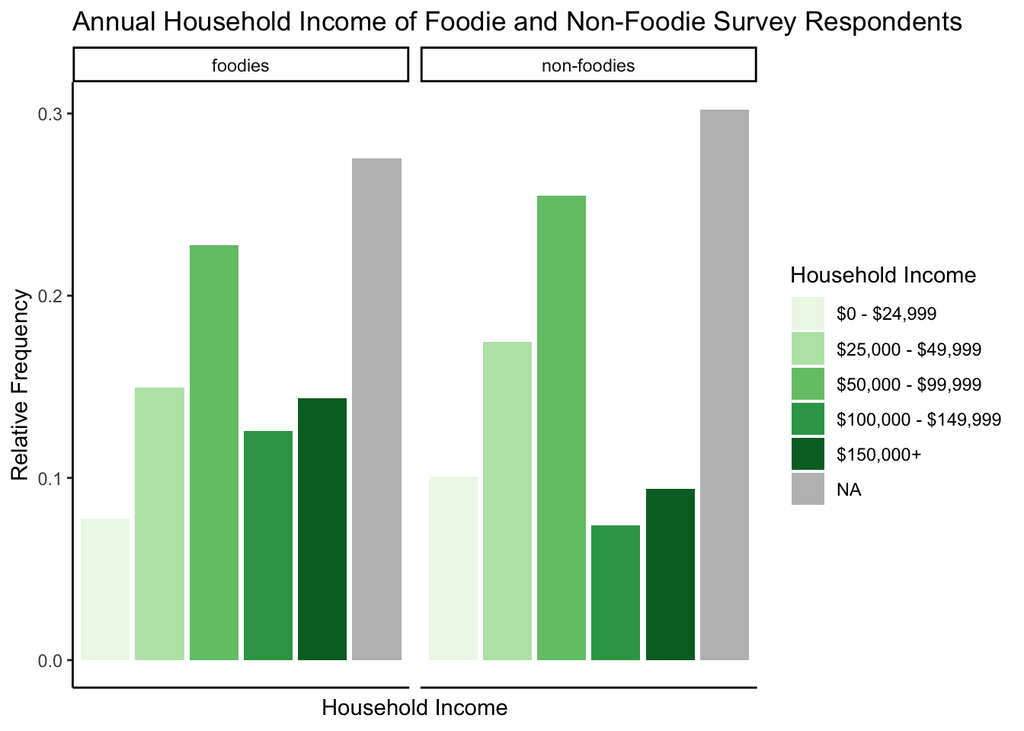

```r
ggplot(food_groups) + geom_bar(aes(x=`Household Income`, fill=`Household Income`, y = (..count..)/tapply(..count..,..PANEL..,sum)[..PANEL..])) + facet_wrap("Group") + scale_fill_brewer(palette="Greens", na.value="gray") + theme_classic() + theme(axis.text.x=element_blank(),  axis.ticks.x=element_blank()) +
  labs(title="Annual Household Income of Foodie and Non-Foodie Survey Respondents", y="Relative Frequency")
```

For both foodies and non-foodies, the income bracket with the largest relative frequency is NA (respondents left the question blank), followed by $50,000 - $99,999. The relative frequencies for the two highest income groups are greater in the foodies distribution than the non-foodies distribution. One interpretation of this observation is that people with more disposable income can travel to foreign countries and eat at restaurants more often. However, income is highly dependent on age for young people and there are many ethnic restaurants with reasonable prices.

## Results & Conclusions

This concludes my demographic analysis of Americans by their knowledge of and interest in cuisines from different parts of the world. From this data, we’ve learned that survey respondents who consider themselves most knowledgable and interested in international food are more likely to be highly educated, live on the coasts, fall in the 30-44 age range, and have a higher income than their counterparts who claim they have limited knowledge and limited interest in foods from other parts of the world. The one categorical variable we considered that did not seem to have any correlation with food knowledge and interest was gender: both men and women seem to be equally likely to consider themselves foodies as the opposite. Many of these observations are unsurprising.

Since correlation does not imply causation, the correlation between self-reported knowledge/interest of international food with higher education and higher income could mean either that people with formal education/incomes consider themselves more worldly or that people who were exposed to global cuisine through their lives were more likely to attend college and earn higher salaries. Of course, interest in international food is likely influenced by other factors that were not measured by this survey, such as time spent traveling/living abroad, presence of family or recent ancestors in other countries, etc.